# Scientific Computing for Biologists Final Project: RNA-seq in Mouse Digits

Alexander Okamoto

3/16/2018

## Project Goals

For my senior thesis project, I am working to understand pectoral fin development in zebrafish through RNA-seq experiments. Since my data has not yet arrived back from the sequencing center, I am working with a dataset provided by Tom Stewart, a postdoc in the Shubin lab. This is a RNA-seq dataset for each digit in developing mouse embryos at stage E13.5. Sequenced reads were already mapped to the mouse genome assembly GRCm38 with Ensembl annotation v85. The manuscript for this project is available at https://www.biorxiv.org/content/early/2017/12/05/224147. Gene identifies were downloaded from Ensembl.

**My goals for the project are to:**

1. Normalize the data for each gene per million transcripts
2. Perform principle component analysis to determine clustering of mouse digit transcriptomes
3. Identify most differentially expressed genes between digit types
4. Create heatmap for most differentially expressed genes
5. Graph expression profiles of most differentially expressed genes

```r
#load packages for project
library(ggplot2) #for data visualization
library(tidyr) # for organizing data
library(dplyr) # for rename function
library(factoextra) #to visualize PCA analysis data
source("https://bioconductor.org/biocLite.R")
```

```
## Bioconductor version 3.6 (BiocInstaller 1.28.0), ?biocLite for help
```

```r
biocLite("edgeR") #to determine differential gene expression
```

```
## BioC_mirror: https://bioconductor.org
```

```
## Using Bioconductor 3.6 (BiocInstaller 1.28.0), R 3.4.1 (2017-06-30).
```

```
## Installing package(s) 'edgeR'
```

```
##
##  /var/folders/bq/md8xbc1j0pjdv8kqmsf1mpfm0000gn/T//RtmppCRWyJ/downloaded_packages
```

```r
library(edgeR)
library(Rmisc) #to calculate standard error
```

**1. Normalize the data for each gene per million transcripts**

```r
#import datafile on mouse embryo digit expression at stage E13.5
seq_data <- read.delim("mm_HTSeq_upload (1).txt")
#import gene references information
all_mouse_genes <- read.csv("mart_export (1).txt", header = TRUE)
#import average gene length for normalization
gene_length_mm <- read.delim('mus_gene_length_median.txt', header = FALSE)

#create master dataset through mm_gene_id shared column
names(gene_length_mm) <- c("mm_gene_id","avg_len")
all_mouse_genes <- rename(all_mouse_genes, replace = c("Gene_stable_ID"="mm_gene_id"))
data <- inner_join(seq_data, all_mouse_genes)
data <- inner_join(data, gene_length_mm)
data$mm_gene_id <- NULL #remove joining variable
rm(all_mouse_genes)
rm(gene_length_mm)
```

```r
# CALCULATING TPM to normalize sequence reads per gene length and total number of reads
fn.TPM_mm <-function(sample) {
  (sample*75*10^6)/(data$avg_len*sum((sample*75)/data$avg_len))
}
TPM_mm <- as.data.frame(sapply(data[1:(length(data)-2)], fn.TPM_mm))
TPM_mm<- as.data.frame(sqrt(TPM_mm))
data[1:15] <- data.frame(TPM_mm)
data <- data[rowSums(data[c(-16,-17)])>0, ] #remove all rows for genes that are not expressed in any sample
rm(TPM_mm) #cleaning environment
```

Data is cleaned, compiled into a single element and converted into transcripts per million for each gene with at least some expression in this dataset.

**2. Perform Principle Component Analysis on Samples**

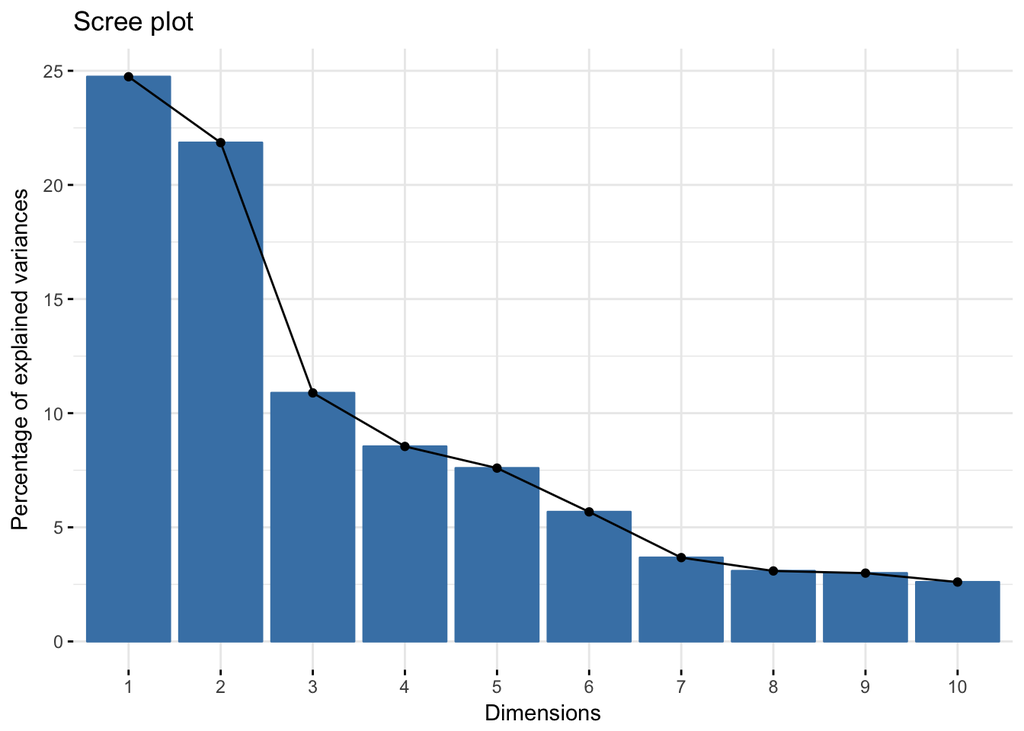

```r
#perform principle component analysis
PCA <-prcomp(t(data[,1:15]))
#graph PCA axes
fviz_eig(PCA)
```

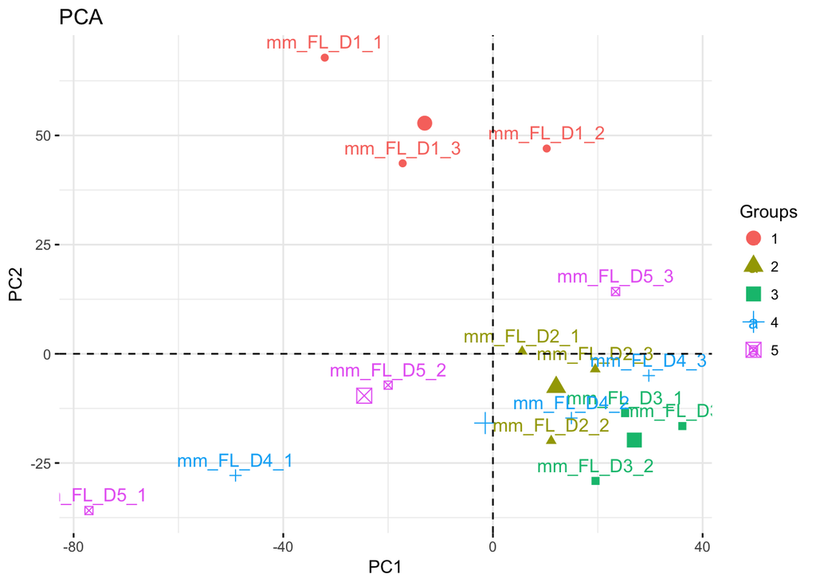

```r
data_groups <- c("1", "1","1","2","2","2","3", "3","3","4","4","4","5", "5","5")
#graph PC1 vs PC2
fviz_pca_ind(PCA, geom = c("point", "text"),
       label = "all", invisible = "none", labelsize = 4,
       pointsize = 2, habillage=data_groups) + labs(title ="PCA", x = "PC1", y = "PC2")
```

This plot shows that digit one has a distinct expression profile, while the other digits do not. Now to find the most differentially expressed genes, I will compare the first and second digits (as the first digit the only one with a distinct gene expression profile as shown by the PCA).

**3. Identify most differentially expressed genes**

```r
exp_groups <- c(1,1,1,2,2,2)
#calculate differential expression
dif_exp <- DGEList(counts=data[2:7], group = exp_groups, genes = data$Gene_name)
dif_exp <- estimateDisp(dif_exp)
```

```
## Design matrix not provided. Switch to the classic mode.
```

```r
dif_exp <- estimateCommonDisp(dif_exp)
dif_exp <- estimateTagwiseDisp(dif_exp)
dif_exp_test <- exactTest(dif_exp)
top_genes <- topTags(dif_exp_test, sort.by="PValue") #identify top dif expressed genes
print(top_genes)
```

```
## Comparison of groups:  2-1
##           genes      logFC   logCPM     PValue FDR
## 263        Pax9 -2.2151003 5.726831 0.01272602   1
## 6354      Tbx15  0.8694926 7.235031 0.01699567   1
## 323      Hoxd12  1.0646503 6.849004 0.01753399   1
## 43217 Mir3084-2 -4.0160195 5.005825 0.03125012   1
## 12605    Hoxd11  0.9208857 6.657512 0.04876806   1
## 28985   Tbx3os1 -1.3593048 5.801919 0.06356877   1
## 1901       Tbx5 -0.4957082 7.695439 0.09184201   1
## 14783    Hoxd10  0.7707064 6.703208 0.10380743   1
## 34180   Snord93 -3.5685949 4.867416 0.12500020   1
## 37526   Mir7025 -3.4466954 4.834677 0.12500020   1
```

```r
top_gene_names <- c("Pax9", "Tbx15", "Hoxd12", "Mir3084-2", "Hoxd11", "Tbx3os1", "Tbx5", "Hoxd10", "Snord93", "Mir7025") #based on top gene results (lowest PValues)

top_gene_data <- data[data$Gene_name %in% top_gene_names,]
#time to tidy the top gene data
top_gene_data$avg_len <- NULL #remove joining variable

top_gene_tidy <- top_gene_data %>% gather(key = 'Sample', value = 'Expression', mm_FL_D1_1:mm_FL_D5_3)
```

**4. Create a heatmap in ggplot2 to analyze differential gene expression**

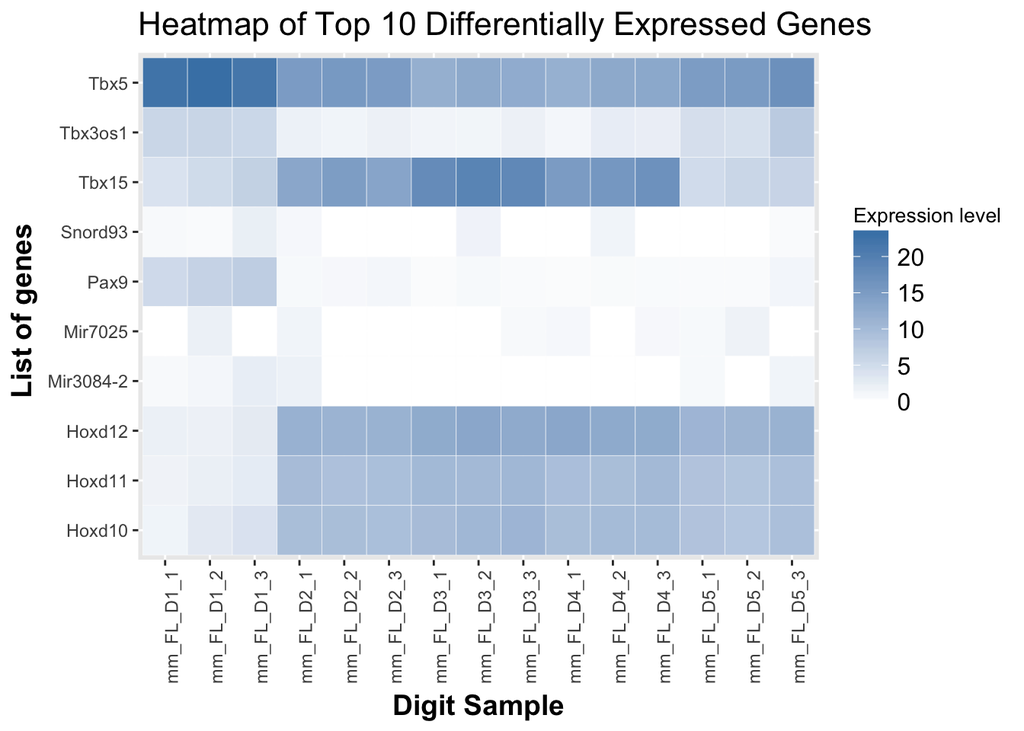

```r
#create heatmap of most differentially expressed genes
ggplot(top_gene_tidy, aes(Sample, Gene_name )) +
geom_tile(aes(fill = Expression), color = "white") +
scale_fill_gradient(low = "white", high = "steelblue") +
ylab("List of genes ") +
xlab("Samples") +
theme(legend.title = element_text(size = 10),
        legend.text = element_text(size = 12),
        plot.title = element_text(size=16),
        axis.title=element_text(size=14,face="bold"),
        axis.text.x = element_text(angle = 90, hjust = 1)) +
labs(fill = "Expression level") + xlab("Digit Sample") + ggtitle("Heatmap of Top 10 Differentially Expressed Genes")
```

**5. Graph expression profiles of most differentially expressed genes**

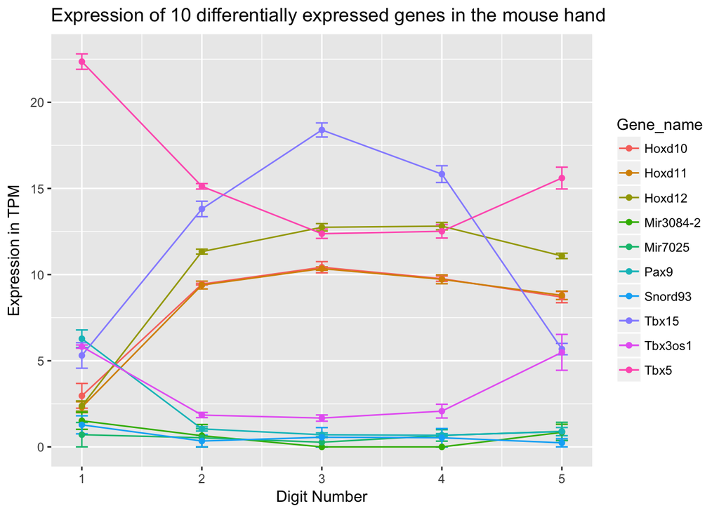

```r
#creates graphs of expression across the limb bud

#tidy data for analysis
top_gene_tidy$Sample[top_gene_tidy$Sample == "mm_FL_D1_1"] <-1
top_gene_tidy$Sample[top_gene_tidy$Sample == "mm_FL_D1_2"] <-1
top_gene_tidy$Sample[top_gene_tidy$Sample == "mm_FL_D1_3"] <-1
top_gene_tidy$Sample[top_gene_tidy$Sample == "mm_FL_D2_1"] <-2
top_gene_tidy$Sample[top_gene_tidy$Sample == "mm_FL_D2_2"] <-2
top_gene_tidy$Sample[top_gene_tidy$Sample == "mm_FL_D2_3"] <-2
top_gene_tidy$Sample[top_gene_tidy$Sample == "mm_FL_D3_1"] <-3
top_gene_tidy$Sample[top_gene_tidy$Sample == "mm_FL_D3_2"] <-3
top_gene_tidy$Sample[top_gene_tidy$Sample == "mm_FL_D3_3"] <-3
top_gene_tidy$Sample[top_gene_tidy$Sample == "mm_FL_D4_1"] <-4
top_gene_tidy$Sample[top_gene_tidy$Sample == "mm_FL_D4_2"] <-4
top_gene_tidy$Sample[top_gene_tidy$Sample == "mm_FL_D4_3"] <-4
top_gene_tidy$Sample[top_gene_tidy$Sample == "mm_FL_D5_1"] <-5
top_gene_tidy$Sample[top_gene_tidy$Sample == "mm_FL_D5_2"] <-5
top_gene_tidy$Sample[top_gene_tidy$Sample == "mm_FL_D5_3"] <-5

#calculate standard error of each sample
top_gene_summary <- summarySE(top_gene_tidy, measurevar="Expression", groupvars=c("Gene_name","Sample"))

# Plot standard error of the mean
ggplot(top_gene_summary, aes(x=as.numeric(Sample), y=Expression, colour=Gene_name)) +
    geom_errorbar(aes(ymin=Expression-se, ymax=Expression+se), width=.1) +
    geom_line() +
    geom_point() + xlab("Digit Number") + ylab("Expression in TPM") + ggtitle("Expression of 10 differentially expressed genes in the mouse hand")
```

**Conclusion**

The most significantly differentially expressed genes generally are differentially expressed between the first digit and the remaining 4 posterior digits as shown by the heat map and gene expression plot. In particular, Tbx5 and Pax9 are strongly upregulated in digit 1 while Hoxd10, Hoxd11, Hoxd12 and Tbx15 are downregulated. This suggests that digit 1 has a distinct expressio profile while digits 2-5 share similar gene expression profiles.